# Analysis(Mediation)

Sicheng, Miguel

5/27/2020

# Environment

## Table 1:

|  | GCS<15 Alive (N=36744) | GCS<15 Died (N=6951) | Normal GCS Alive (N=58853) | Normal GCS Died (N=2903) | Overall Alive (N=95597) | Overall Died (N=9854) |
| --- | --- | --- | --- | --- | --- | --- |
| sodium_cat |  |  |  |  |  |  |
| 1 | 447 (1.2%) | 58 (0.8%) | 756 (1.3%) | 45 (1.6%) | 1203 (1.3%) | 103 (1.0%) |
| 2 | 543 (1.5%) | 136 (2.0%) | 1129 (1.9%) | 95 (3.3%) | 1672 (1.7%) | 231 (2.3%) |
| 3 | 1647 (4.5%) | 458 (6.6%) | 3769 (6.4%) | 323 (11.1%) | 5416 (5.7%) | 781 (7.9%) |
| 4 | 6487 (17.7%) | 1372 (19.7%) | 12827 (21.8%) | 806 (27.8%) | 19314 (20.2%) | 2178 (22.1%) |
| 5 | 15704 (42.7%) | 2501 (36.0%) | 27634 (47.0%) | 1075 (37.0%) | 43338 (45.3%) | 3576 (36.3%) |
| 6 | 9382 (25.5%) | 1671 (24.0%) | 11759 (20.0%) | 465 (16.0%) | 21141 (22.1%) | 2136 (21.7%) |
| 7 | 1768 (4.8%) | 527 (7.6%) | 862 (1.5%) | 76 (2.6%) | 2630 (2.8%) | 603 (6.1%) |
| 8 | 766 (2.1%) | 228 (3.3%) | 117 (0.2%) | 18 (0.6%) | 883 (0.9%) | 246 (2.5%) |
| age |  |  |  |  |  |  |
| Mean (SD) | 63.5 (17.6) | 68.9 (15.7) | 61.7 (17.4) | 69.8 (14.4) | 62.4 (17.5) | 69.2 (15.3) |
| Median [Min, Max] | 65.0 [16.0, 93.0] | 71.0 [16.0, 93.0] | 64.0 [16.0, 93.0] | 71.0 [19.0, 93.0] | 64.0 [16.0, 93.0] | 71.0 [16.0, 93.0] |
| gender |  |  |  |  |  |  |
| female | 16969 (46.2%) | 3201 (46.1%) | 26906 (45.7%) | 1335 (46.0%) | 43875 (45.9%) | 4536 (46.0%) |
| male | 19775 (53.8%) | 3750 (53.9%) | 31947 (54.3%) | 1568 (54.0%) | 51722 (54.1%) | 5318 (54.0%) |
| AP_grp |  |  |  |  |  |  |
| ACS | 470 (1.3%) | 100 (1.4%) | 5034 (8.6%) | 140 (4.8%) | 5504 (5.8%) | 240 (2.4%) |
| CardiacArrest | 1656 (4.5%) | 1403 (20.2%) | 3791 (6.4%) | 191 (6.6%) | 5447 (5.7%) | 1594 (16.2%) |
| CHF | 1000 (2.7%) | 254 (3.7%) | 2903 (4.9%) | 229 (7.9%) | 3903 (4.1%) | 483 (4.9%) |
| CVA | 2844 (7.7%) | 721 (10.4%) | 3857 (6.6%) | 79 (2.7%) | 6701 (7.0%) | 800 (8.1%) |
| GIBleed | 1209 (3.3%) | 236 (3.4%) | 3980 (6.8%) | 168 (5.8%) | 5189 (5.4%) | 404 (4.1%) |
| Other | 18384 (50.0%) | 1510 (21.7%) | 25188 (42.8%) | 716 (24.7%) | 43572 (45.6%) | 2226 (22.6%) |
| PNA | 1296 (3.5%) | 298 (4.3%) | 1778 (3.0%) | 235 (8.1%) | 3074 (3.2%) | 533 (5.4%) |
| RespMedOther | 2567 (7.0%) | 587 (8.4%) | 3152 (5.4%) | 285 (9.8%) | 5719 (6.0%) | 872 (8.8%) |
| Sepsis | 5362 (14.6%) | 1550 (22.3%) | 6795 (11.5%) | 815 (28.1%) | 12157 (12.7%) | 2365 (24.0%) |
| Trauma | 1956 (5.3%) | 292 (4.2%) | 2375 (4.0%) | 45 (1.6%) | 4331 (4.5%) | 337 (3.4%) |
| ethnicity |  |  |  |  |  |  |
| Caucasian | 28314 (77.1%) | 5411 (77.8%) | 45101 (76.6%) | 2375 (81.8%) | 73415 (76.8%) | 7786 (79.0%) |
| Not Caucasian | 8430 (22.9%) | 1540 (22.2%) | 13752 (23.4%) | 528 (18.2%) | 22182 (23.2%) | 2068 (21.0%) |
| mechvent_day01 |  |  |  |  |  |  |
| 0 | 19827 (54.0%) | 2385 (34.3%) | 54805 (93.1%) | 2233 (76.9%) | 74632 (78.1%) | 4618 (46.9%) |
| 1 | 16917 (46.0%) | 4566 (65.7%) | 4048 (6.9%) | 670 (23.1%) | 20965 (21.9%) | 5236 (53.1%) |
| unittype |  |  |  |  |  |  |
| Cardiac ICU | 1838 (5.0%) | 490 (7.0%) | 5180 (8.8%) | 259 (8.9%) | 7018 (7.3%) | 749 (7.6%) |
| CCU-CTICU | 2423 (6.6%) | 454 (6.5%) | 4361 (7.4%) | 202 (7.0%) | 6784 (7.1%) | 656 (6.7%) |
| CSICU | 1749 (4.8%) | 197 (2.8%) | 2395 (4.1%) | 100 (3.4%) | 4144 (4.3%) | 297 (3.0%) |
| CTICU | 940 (2.6%) | 109 (1.6%) | 1410 (2.4%) | 50 (1.7%) | 2350 (2.5%) | 159 (1.6%) |
| Med-Surg ICU | 20848 (56.7%) | 3891 (56.0%) | 34426 (58.5%) | 1745 (60.1%) | 55274 (57.8%) | 5636 (57.2%) |
| MICU | 3287 (8.9%) | 801 (11.5%) | 4215 (7.2%) | 306 (10.5%) | 7502 (7.8%) | 1107 (11.2%) |
| Neuro ICU | 3261 (8.9%) | 571 (8.2%) | 3483 (5.9%) | 101 (3.5%) | 6744 (7.1%) | 672 (6.8%) |
| SICU | 2398 (6.5%) | 438 (6.3%) | 3383 (5.7%) | 140 (4.8%) | 5781 (6.0%) | 578 (5.9%) |
| as.factor(charlson_chf1) |  |  |  |  |  |  |
| 0 | 31451 (85.6%) | 5609 (80.7%) | 50472 (85.8%) | 2254 (77.6%) | 81923 (85.7%) | 7863 (79.8%) |
| 1 | 5293 (14.4%) | 1342 (19.3%) | 8381 (14.2%) | 649 (22.4%) | 13674 (14.3%) | 1991 (20.2%) |
| as.factor(charlson_liver1) |  |  |  |  |  |  |
| 0 | 35935 (97.8%) | 6678 (96.1%) | 57813 (98.2%) | 2769 (95.4%) | 93748 (98.1%) | 9447 (95.9%) |
| 1 | 809 (2.2%) | 273 (3.9%) | 1040 (1.8%) | 134 (4.6%) | 1849 (1.9%) | 407 (4.1%) |

# Mediation package

- *ACME:* Average Causal Mediation Effects. This is the indirect effect of the IV on the outcome that goes through the mediator.
- *ADE:* Average direct effects. It describes the direct effect of the IV on the Outcome.
- *Total Effect* the Total Effect (direct + indirect) of the IV on the Outcome.
- *Prop. Mediated* describes the proportion of the effect of the IV on the Outcome that goes through the mediator. It’s calculated by dividing the ACME through the total effect.

## Mediation analysis: Baseline sodium_cat_1

[output not shown]

```
##
## Call:
## glm(formula = as.factor(hosp_mortality) ~ gcs_baseline + sodium_cat +
##     age + AP_grp + gender + ethnicity + unittype + charlson_liver1 +
##     charlson_chf1 + mechvent_day01, family = binomial("probit"),
##     data = sodium_cat_1_df)
##
## Deviance Residuals:
##     Min       1Q   Median       3Q      Max
## -1.5596  -0.4137  -0.2635  -0.1639   3.4101
##
## Coefficients:
##                          Estimate Std. Error z value Pr(>|z|)
## (Intercept)            -1.4698454  0.1004741 -14.629  < 2e-16 ***
## gcs_baseline           -0.0794858  0.0029239 -27.185  < 2e-16 ***
## sodium_cat5            -0.2429471  0.0568774  -4.271 1.94e-05 ***
## age                     0.0150538  0.0006326  23.798  < 2e-16 ***
## AP_grpCardiacArrest     0.5082131  0.0548271   9.269  < 2e-16 ***
## AP_grpCHF               0.3062264  0.0639351   4.790 1.67e-06 ***
## AP_grpCVA               0.2323770  0.0579244   4.012 6.03e-05 ***
## AP_grpGIBleed           0.1332882  0.0632589   2.107  0.03512 *
## AP_grpOther            -0.2060185  0.0508510  -4.051 5.09e-05 ***
## AP_grpPNA               0.4942036  0.0631115   7.831 4.85e-15 ***
## AP_grpRespMedOther      0.2751384  0.0580457   4.740 2.14e-06 ***
## AP_grpSepsis            0.5152158  0.0523033   9.851  < 2e-16 ***
## AP_grpTrauma            0.0429822  0.0659123   0.652  0.51433
## gendermale             -0.0138485  0.0188713  -0.734  0.46304
## ethnicityNot Caucasian -0.0278901  0.0233801  -1.193  0.23291
## unittypeCCU-CTICU      -0.1119630  0.0493725  -2.268  0.02335 *
## unittypeCSICU          -0.2695449  0.0609671  -4.421 9.82e-06 ***
## unittypeCTICU          -0.2268991  0.0765033  -2.966  0.00302 **
## unittypeMed-Surg ICU   -0.0486578  0.0370358  -1.314  0.18891
## unittypeMICU            0.0743192  0.0462245   1.608  0.10788
## unittypeNeuro ICU       0.0477133  0.0514337   0.928  0.35358
## unittypeSICU            0.0099717  0.0518655   0.192  0.84754
## charlson_liver1         0.5296529  0.0588057   9.007  < 2e-16 ***
## charlson_chf1           0.0703678  0.0253079   2.780  0.00543 **
## mechvent_day011         0.3759937  0.0256061  14.684  < 2e-16 ***
## ---
## Signif. codes:  0 '***' 0.001 '**' 0.01 '*' 0.05 '.' 0.1 ' ' 1
##
## (Dispersion parameter for binomial family taken to be 1)
##
##     Null deviance: 26003  on 48219  degrees of freedom
## Residual deviance: 21578  on 48195  degrees of freedom
## AIC: 21628
##
## Number of Fisher Scoring iterations: 6
```

```
##                               Estimate  95% CI Lower 95% CI Upper p-value
## ACME (control)            0.0010929082 -0.0005856601  0.003105629    0.22
## ACME (treated)            0.0008279747 -0.0004071493  0.002254013    0.22
## ADE (control)            -0.0334756095 -0.0525410795 -0.019948770    0.00
## ADE (treated)            -0.0337405431 -0.0531224567 -0.020075816    0.00
## Total Effect             -0.0326476348 -0.0505317039 -0.019212870    0.00
## Prop. Mediated (control) -0.0334885512 -0.1003922086  0.012627671    0.22
## Prop. Mediated (treated) -0.0254446300 -0.0767984387  0.009246536    0.22
## ACME (average)            0.0009604415 -0.0004964047  0.002679821    0.22
## ADE (average)            -0.0336080763 -0.0526968475 -0.020011692    0.00
## Prop. Mediated (average) -0.0294665906 -0.0876950149  0.010861363    0.22
```

## Mediation analysis: Baseline sodium_cat_2

```
##
## Call:
## glm(formula = as.factor(hosp_mortality) ~ gcs_baseline + age +
##     AP_grp + gender + ethnicity + unittype + charlson_liver1 +
##     charlson_chf1 + mechvent_day01, family = binomial("probit"),
##     data = sodium_cat_2_df)
##
## Deviance Residuals:
##     Min       1Q   Median       3Q      Max
## -1.5766  -0.4194  -0.2675  -0.1663   3.3850
##
## Coefficients:
##                          Estimate Std. Error z value Pr(>|z|)
## (Intercept)            -1.7105750  0.0824127 -20.756  < 2e-16 ***
## gcs_baseline           -0.0779552  0.0028834 -27.035  < 2e-16 ***
## age                     0.0149905  0.0006219  24.103  < 2e-16 ***
## AP_grpCardiacArrest     0.5087902  0.0540862   9.407  < 2e-16 ***
## AP_grpCHF               0.3223955  0.0628643   5.128 2.92e-07 ***
## AP_grpCVA               0.2278968  0.0572543   3.980 6.88e-05 ***
## AP_grpGIBleed           0.1306358  0.0623337   2.096 0.036104 *
## AP_grpOther            -0.1855509  0.0500611  -3.706 0.000210 ***
## AP_grpPNA               0.4667990  0.0626090   7.456 8.93e-14 ***
## AP_grpRespMedOther      0.2646078  0.0573281   4.616 3.92e-06 ***
## AP_grpSepsis            0.5266585  0.0514276  10.241  < 2e-16 ***
## AP_grpTrauma            0.0458864  0.0651889   0.704 0.481495
## gendermale             -0.0125563  0.0186019  -0.675 0.499675
## ethnicityNot Caucasian -0.0250216  0.0230061  -1.088 0.276767
## unittypeCCU-CTICU      -0.1287691  0.0487225  -2.643 0.008220 **
## unittypeCSICU          -0.2862497  0.0599602  -4.774 1.81e-06 ***
## unittypeCTICU          -0.2629736  0.0760501  -3.458 0.000544 ***
## unittypeMed-Surg ICU   -0.0567941  0.0364444  -1.558 0.119144
## unittypeMICU            0.0754211  0.0454249   1.660 0.096845 .
## unittypeNeuro ICU       0.0231002  0.0507950   0.455 0.649273
## unittypeSICU            0.0032552  0.0510501   0.064 0.949158
## charlson_liver1         0.5388588  0.0574538   9.379  < 2e-16 ***
## charlson_chf1           0.0707314  0.0249358   2.837 0.004561 **
## mechvent_day011         0.3839339  0.0252224  15.222  < 2e-16 ***
## ---
## Signif. codes:  0 '***' 0.001 '**' 0.01 '*' 0.05 '.' 0.1 ' ' 1
##
## (Dispersion parameter for binomial family taken to be 1)
##
##     Null deviance: 26734  on 48816  degrees of freedom
## Residual deviance: 22232  on 48793  degrees of freedom
## AIC: 22280
##
## Number of Fisher Scoring iterations: 6
```

```
##
## Call:
## glm(formula = as.factor(hosp_mortality) ~ gcs_baseline + sodium_cat +
##     age + AP_grp + gender + ethnicity + unittype + charlson_liver1 +
##     charlson_chf1 + mechvent_day01, family = binomial("probit"),
##     data = sodium_cat_2_df)
##
## Deviance Residuals:
##     Min       1Q   Median       3Q      Max
## -1.5633  -0.4175  -0.2659  -0.1647   3.4038
##
## Coefficients:
##                          Estimate Std. Error z value Pr(>|z|)
## (Intercept)            -1.3462853  0.0917943 -14.666  < 2e-16 ***
## gcs_baseline           -0.0782848  0.0028909 -27.080  < 2e-16 ***
## sodium_cat5            -0.3854248  0.0424968  -9.070  < 2e-16 ***
## age                     0.0152315  0.0006246  24.386  < 2e-16 ***
## AP_grpCardiacArrest     0.5006837  0.0542317   9.232  < 2e-16 ***
## AP_grpCHF               0.3074779  0.0630684   4.875 1.09e-06 ***
## AP_grpCVA               0.2269857  0.0573910   3.955 7.65e-05 ***
## AP_grpGIBleed           0.1266147  0.0624698   2.027  0.04268 *
## AP_grpOther            -0.2005702  0.0502092  -3.995 6.48e-05 ***
## AP_grpPNA               0.4579580  0.0627430   7.299 2.90e-13 ***
## AP_grpRespMedOther      0.2568071  0.0574787   4.468 7.90e-06 ***
## AP_grpSepsis            0.5063720  0.0516101   9.811  < 2e-16 ***
## AP_grpTrauma            0.0444625  0.0653366   0.681  0.49618
## gendermale             -0.0110540  0.0186430  -0.593  0.55323
## ethnicityNot Caucasian -0.0235105  0.0230481  -1.020  0.30770
## unittypeCCU-CTICU      -0.1269473  0.0488358  -2.599  0.00934 **
## unittypeCSICU          -0.2809779  0.0600883  -4.676 2.92e-06 ***
## unittypeCTICU          -0.2542651  0.0762215  -3.336  0.00085 ***
## unittypeMed-Surg ICU   -0.0587853  0.0365313  -1.609  0.10758
## unittypeMICU            0.0716537  0.0455401   1.573  0.11562
## unittypeNeuro ICU       0.0262069  0.0509267   0.515  0.60683
## unittypeSICU            0.0074832  0.0511812   0.146  0.88376
## charlson_liver1         0.5109106  0.0575982   8.870  < 2e-16 ***
## charlson_chf1           0.0712795  0.0249790   2.854  0.00432 **
## mechvent_day011         0.3897998  0.0253053  15.404  < 2e-16 ***
## ---
## Signif. codes:  0 '***' 0.001 '**' 0.01 '*' 0.05 '.' 0.1 ' ' 1
##
## (Dispersion parameter for binomial family taken to be 1)
##
##     Null deviance: 26734  on 48816  degrees of freedom
## Residual deviance: 22155  on 48792  degrees of freedom
## AIC: 22205
##
## Number of Fisher Scoring iterations: 6
```

```
##                               Estimate  95% CI Lower 95% CI Upper p-value
## ACME (control)            0.0006634081 -0.0010198226  0.002136728    0.39
## ACME (treated)            0.0004333295 -0.0006682300  0.001343561    0.39
## ADE (control)            -0.0593413267 -0.0773513984 -0.044847314    0.00
## ADE (treated)            -0.0595714052 -0.0775461783 -0.044987187    0.00
## Total Effect             -0.0589079972 -0.0770577089 -0.044230430    0.00
## Prop. Mediated (control) -0.0116969833 -0.0395731751  0.016829303    0.39
## Prop. Mediated (treated) -0.0076244807 -0.0271032804  0.010813466    0.39
## ACME (average)            0.0005483688 -0.0008350186  0.001740144    0.39
## ADE (average)            -0.0594563660 -0.0774487883 -0.044917251    0.00
## Prop. Mediated (average) -0.0096607320 -0.0331321474  0.014085999    0.39
```

## Mediation analysis: Baseline sodium_cat_3

```
##
## Call:
## glm(formula = as.factor(hosp_mortality) ~ gcs_baseline + age +
##     AP_grp + gender + ethnicity + unittype + charlson_liver1 +
##     charlson_chf1 + mechvent_day01, family = binomial("probit"),
##     data = sodium_cat_3_df)
##
## Deviance Residuals:
##     Min       1Q   Median       3Q      Max
## -1.5875  -0.4322  -0.2779  -0.1735   3.3525
##
## Coefficients:
##                          Estimate Std. Error z value Pr(>|z|)
## (Intercept)            -1.6533216  0.0777136 -21.275  < 2e-16 ***
## gcs_baseline           -0.0757469  0.0027297 -27.749  < 2e-16 ***
## age                     0.0143042  0.0005846  24.468  < 2e-16 ***
## AP_grpCardiacArrest     0.4752425  0.0508515   9.346  < 2e-16 ***
## AP_grpCHF               0.3165672  0.0583373   5.426 5.75e-08 ***
## AP_grpCVA               0.1904756  0.0541607   3.517 0.000437 ***
## AP_grpGIBleed           0.0920638  0.0586434   1.570 0.116440
## AP_grpOther            -0.2076870  0.0468242  -4.435 9.19e-06 ***
## AP_grpPNA               0.4481087  0.0586804   7.636 2.23e-14 ***
## AP_grpRespMedOther      0.2665417  0.0534710   4.985 6.20e-07 ***
## AP_grpSepsis            0.5094817  0.0478237  10.653  < 2e-16 ***
## AP_grpTrauma           -0.0029964  0.0621350  -0.048 0.961538
## gendermale             -0.0161953  0.0175027  -0.925 0.354809
## ethnicityNot Caucasian -0.0454441  0.0217368  -2.091 0.036559 *
## unittypeCCU-CTICU      -0.1004912  0.0458404  -2.192 0.028365 *
## unittypeCSICU          -0.2621337  0.0564674  -4.642 3.45e-06 ***
## unittypeCTICU          -0.1863481  0.0699997  -2.662 0.007765 **
## unittypeMed-Surg ICU   -0.0454304  0.0343773  -1.322 0.186327
## unittypeMICU            0.0789999  0.0426565   1.852 0.064025 .
## unittypeNeuro ICU       0.0532520  0.0482005   1.105 0.269245
## unittypeSICU            0.0155689  0.0480437   0.324 0.745894
## charlson_liver1         0.5339982  0.0518197  10.305  < 2e-16 ***
## charlson_chf1           0.0842962  0.0232368   3.628 0.000286 ***
## mechvent_day011         0.3960540  0.0237060  16.707  < 2e-16 ***
## ---
## Signif. codes:  0 '***' 0.001 '**' 0.01 '*' 0.05 '.' 0.1 ' ' 1
##
## (Dispersion parameter for binomial family taken to be 1)
##
##     Null deviance: 30137  on 53110  degrees of freedom
## Residual deviance: 25190  on 53087  degrees of freedom
## AIC: 25238
##
## Number of Fisher Scoring iterations: 6
```

```
##
## Call:
## glm(formula = as.factor(hosp_mortality) ~ gcs_baseline + sodium_cat +
##     age + AP_grp + gender + ethnicity + unittype + charlson_liver1 +
##     charlson_chf1 + mechvent_day01, family = binomial("probit"),
##     data = sodium_cat_3_df)
##
## Deviance Residuals:
##     Min       1Q   Median       3Q      Max
## -1.7711  -0.4270  -0.2740  -0.1695   3.3842
##
## Coefficients:
##                          Estimate Std. Error z value Pr(>|z|)
## (Intercept)            -1.3521199  0.0812196 -16.648  < 2e-16 ***
## gcs_baseline           -0.0770482  0.0027437 -28.082  < 2e-16 ***
## sodium_cat5            -0.3420917  0.0246345 -13.887  < 2e-16 ***
## age                     0.0146741  0.0005892  24.903  < 2e-16 ***
## AP_grpCardiacArrest     0.4643732  0.0512091   9.068  < 2e-16 ***
## AP_grpCHF               0.2896277  0.0587377   4.931 8.19e-07 ***
## AP_grpCVA               0.1974062  0.0545337   3.620 0.000295 ***
## AP_grpGIBleed           0.0834075  0.0590105   1.413 0.157528
## AP_grpOther            -0.2224406  0.0471646  -4.716 2.40e-06 ***
## AP_grpPNA               0.4326447  0.0590172   7.331 2.29e-13 ***
## AP_grpRespMedOther      0.2496281  0.0538711   4.634 3.59e-06 ***
## AP_grpSepsis            0.4673692  0.0482664   9.683  < 2e-16 ***
## AP_grpTrauma            0.0035420  0.0625018   0.057 0.954807
## gendermale             -0.0129098  0.0175787  -0.734 0.462705
## ethnicityNot Caucasian -0.0433241  0.0218239  -1.985 0.047126 *
## unittypeCCU-CTICU      -0.0982706  0.0460702  -2.133 0.032920 *
## unittypeCSICU          -0.2580357  0.0567430  -4.547 5.43e-06 ***
## unittypeCTICU          -0.1833908  0.0704839  -2.602 0.009271 **
## unittypeMed-Surg ICU   -0.0475958  0.0345268  -1.379 0.168043
## unittypeMICU            0.0687127  0.0428313   1.604 0.108656
## unittypeNeuro ICU       0.0557214  0.0484581   1.150 0.250190
## unittypeSICU            0.0088816  0.0482914   0.184 0.854078
## charlson_liver1         0.4873452  0.0520193   9.369  < 2e-16 ***
## charlson_chf1           0.0784510  0.0233253   3.363 0.000770 ***
## mechvent_day011         0.4021021  0.0238287  16.875  < 2e-16 ***
## ---
## Signif. codes:  0 '***' 0.001 '**' 0.01 '*' 0.05 '.' 0.1 ' ' 1
##
## (Dispersion parameter for binomial family taken to be 1)
##
##     Null deviance: 30137  on 53110  degrees of freedom
## Residual deviance: 25005  on 53086  degrees of freedom
## AIC: 25055
##
## Number of Fisher Scoring iterations: 6
```

```
##                              Estimate  95% CI Lower 95% CI Upper p-value
## ACME (control)            0.002297630  0.0013313733  0.003439283       0
## ACME (treated)            0.001573796  0.0009062449  0.002343681       0
## ADE (control)            -0.050459473 -0.0584918347 -0.042915588       0
## ADE (treated)            -0.051183307 -0.0589821484 -0.043555190       0
## Total Effect             -0.048885677 -0.0571576450 -0.041203464       0
## Prop. Mediated (control) -0.045855602 -0.0699710860 -0.027521276       0
## Prop. Mediated (treated) -0.031542307 -0.0491002527 -0.018853265       0
## ACME (average)            0.001935713  0.0011407079  0.002883687       0
## ADE (average)            -0.050821390 -0.0587380357 -0.043225646       0
## Prop. Mediated (average) -0.038698955 -0.0591748810 -0.023328100       0
```

## Mediation analysis: Baseline sodium_cat_4

```
##
## Call:
## glm(formula = as.factor(hosp_mortality) ~ gcs_baseline + age +
##     AP_grp + gender + ethnicity + unittype + charlson_liver1 +
##     charlson_chf1 + mechvent_day01, family = binomial("probit"),
##     data = sodium_cat_4_df)
##
## Deviance Residuals:
##     Min       1Q   Median       3Q      Max
## -1.5708  -0.4364  -0.2842  -0.1788   3.4457
##
## Coefficients:
##                          Estimate Std. Error z value Pr(>|z|)
## (Intercept)            -1.5955934  0.0673707 -23.684  < 2e-16 ***
## gcs_baseline           -0.0779412  0.0024003 -32.472  < 2e-16 ***
## age                     0.0142095  0.0005119  27.758  < 2e-16 ***
## AP_grpCardiacArrest     0.4637616  0.0437556  10.599  < 2e-16 ***
## AP_grpCHF               0.2813592  0.0504451   5.578 2.44e-08 ***
## AP_grpCVA               0.1806420  0.0469260   3.850 0.000118 ***
## AP_grpGIBleed           0.0705861  0.0505312   1.397 0.162450
## AP_grpOther            -0.2265564  0.0402385  -5.630 1.80e-08 ***
## AP_grpPNA               0.4545573  0.0502786   9.041  < 2e-16 ***
## AP_grpRespMedOther      0.2545494  0.0461277   5.518 3.42e-08 ***
## AP_grpSepsis            0.4684651  0.0410137  11.422  < 2e-16 ***
## AP_grpTrauma           -0.0309242  0.0547371  -0.565 0.572102
## gendermale              0.0048161  0.0152904   0.315 0.752780
## ethnicityNot Caucasian -0.0397023  0.0189834  -2.091 0.036490 *
## unittypeCCU-CTICU      -0.0843113  0.0396325  -2.127 0.033393 *
## unittypeCSICU          -0.2411083  0.0497440  -4.847 1.25e-06 ***
## unittypeCTICU          -0.1720513  0.0604083  -2.848 0.004398 **
## unittypeMed-Surg ICU   -0.0424302  0.0297800  -1.425 0.154219
## unittypeMICU            0.0824904  0.0369020   2.235 0.025392 *
## unittypeNeuro ICU       0.0452697  0.0423888   1.068 0.285537
## unittypeSICU            0.0106380  0.0415208   0.256 0.797788
## charlson_liver1         0.5257498  0.0453027  11.605  < 2e-16 ***
## charlson_chf1           0.0823242  0.0202510   4.065 4.80e-05 ***
## mechvent_day011         0.3760397  0.0206780  18.185  < 2e-16 ***
## ---
## Signif. codes:  0 '***' 0.001 '**' 0.01 '*' 0.05 '.' 0.1 ' ' 1
##
## (Dispersion parameter for binomial family taken to be 1)
##
##     Null deviance: 39499  on 68405  degrees of freedom
## Residual deviance: 33095  on 68382  degrees of freedom
## AIC: 33143
##
## Number of Fisher Scoring iterations: 6
```

```
##
## Call:
## glm(formula = as.factor(hosp_mortality) ~ gcs_baseline + sodium_cat +
##     age + AP_grp + gender + ethnicity + unittype + charlson_liver1 +
##     charlson_chf1 + mechvent_day01, family = binomial("probit"),
##     data = sodium_cat_4_df)
##
## Deviance Residuals:
##     Min       1Q   Median       3Q      Max
## -1.5642  -0.4350  -0.2819  -0.1759   3.3675
##
## Coefficients:
##                          Estimate Std. Error z value Pr(>|z|)
## (Intercept)            -1.4747177  0.0684623 -21.541  < 2e-16 ***
## gcs_baseline           -0.0786845  0.0024077 -32.681  < 2e-16 ***
## sodium_cat5            -0.1788333  0.0159862 -11.187  < 2e-16 ***
## age                     0.0143491  0.0005138  27.930  < 2e-16 ***
## AP_grpCardiacArrest     0.4592345  0.0439379  10.452  < 2e-16 ***
## AP_grpCHF               0.2708185  0.0506158   5.350 8.77e-08 ***
## AP_grpCVA               0.1874284  0.0471310   3.977 6.99e-05 ***
## AP_grpGIBleed           0.0661777  0.0507237   1.305  0.19200
## AP_grpOther            -0.2292062  0.0403982  -5.674 1.40e-08 ***
## AP_grpPNA               0.4465903  0.0504325   8.855  < 2e-16 ***
## AP_grpRespMedOther      0.2496079  0.0462994   5.391 7.00e-08 ***
## AP_grpSepsis            0.4483508  0.0412162  10.878  < 2e-16 ***
## AP_grpTrauma           -0.0183070  0.0549222  -0.333  0.73889
## gendermale              0.0052762  0.0153236   0.344  0.73061
## ethnicityNot Caucasian -0.0383676  0.0190200  -2.017  0.04367 *
## unittypeCCU-CTICU      -0.0819991  0.0397283  -2.064  0.03902 *
## unittypeCSICU          -0.2308877  0.0498408  -4.633 3.61e-06 ***
## unittypeCTICU          -0.1741055  0.0606397  -2.871  0.00409 **
## unittypeMed-Surg ICU   -0.0406793  0.0298453  -1.363  0.17288
## unittypeMICU            0.0783051  0.0369874   2.117  0.03425 *
## unittypeNeuro ICU       0.0502555  0.0425181   1.182  0.23721
## unittypeSICU            0.0045857  0.0416219   0.110  0.91227
## charlson_liver1         0.5080392  0.0453508  11.202  < 2e-16 ***
## charlson_chf1           0.0801134  0.0202846   3.949 7.83e-05 ***
## mechvent_day011         0.3797774  0.0207242  18.325  < 2e-16 ***
## ---
## Signif. codes:  0 '***' 0.001 '**' 0.01 '*' 0.05 '.' 0.1 ' ' 1
##
## (Dispersion parameter for binomial family taken to be 1)
##
##     Null deviance: 39499  on 68405  degrees of freedom
## Residual deviance: 32971  on 68381  degrees of freedom
## AIC: 33021
##
## Number of Fisher Scoring iterations: 6
```

```
##                               Estimate  95% CI Lower 95% CI Upper p-value
## ACME (control)            0.0009484531  0.0004620178  0.001428939       0
## ACME (treated)            0.0007695687  0.0003761212  0.001155141       0
## ADE (control)            -0.0243992974 -0.0288327510 -0.020398089       0
## ADE (treated)            -0.0245781818 -0.0290301676 -0.020542891       0
## Total Effect             -0.0236297287 -0.0280269305 -0.019657934       0
## Prop. Mediated (control) -0.0393744779 -0.0629500459 -0.019144153       0
## Prop. Mediated (treated) -0.0318149320 -0.0516579234 -0.015262217       0
## ACME (average)            0.0008590109  0.0004190695  0.001297615       0
## ADE (average)            -0.0244887396 -0.0289314593 -0.020470053       0
## Prop. Mediated (average) -0.0355947049 -0.0573039846 -0.017154058       0
```

## Mediation analysis: Baseline sodium_cat_6

```
##
## Call:
## glm(formula = as.factor(hosp_mortality) ~ gcs_baseline + age +
##     AP_grp + gender + ethnicity + unittype + charlson_liver1 +
##     charlson_chf1 + mechvent_day01, family = binomial("probit"),
##     data = sodium_cat_6_df)
##
## Deviance Residuals:
##     Min       1Q   Median       3Q      Max
## -1.5618  -0.4243  -0.2691  -0.1658   3.4680
##
## Coefficients:
##                          Estimate Std. Error z value Pr(>|z|)
## (Intercept)            -1.7073030  0.0687835 -24.821  < 2e-16 ***
## gcs_baseline           -0.0820264  0.0023250 -35.280  < 2e-16 ***
## age                     0.0147861  0.0005108  28.945  < 2e-16 ***
## AP_grpCardiacArrest     0.5793325  0.0466649  12.415  < 2e-16 ***
## AP_grpCHF               0.3136940  0.0543042   5.777 7.62e-09 ***
## AP_grpCVA               0.2680497  0.0492834   5.439 5.36e-08 ***
## AP_grpGIBleed           0.1633062  0.0530935   3.076 0.002099 **
## AP_grpOther            -0.1546880  0.0437458  -3.536 0.000406 ***
## AP_grpPNA               0.5176305  0.0536304   9.652  < 2e-16 ***
## AP_grpRespMedOther      0.2970662  0.0493363   6.021 1.73e-09 ***
## AP_grpSepsis            0.5589792  0.0450413  12.410  < 2e-16 ***
## AP_grpTrauma            0.0579190  0.0550497   1.052 0.292743
## gendermale             -0.0123485  0.0153590  -0.804 0.421401
## ethnicityNot Caucasian -0.0131172  0.0188065  -0.697 0.485502
## unittypeCCU-CTICU      -0.1039491  0.0404802  -2.568 0.010232 *
## unittypeCSICU          -0.3484458  0.0497741  -7.001 2.55e-12 ***
## unittypeCTICU          -0.2111264  0.0638845  -3.305 0.000950 ***
## unittypeMed-Surg ICU   -0.0339463  0.0302329  -1.123 0.261511
## unittypeMICU            0.0911858  0.0379323   2.404 0.016221 *
## unittypeNeuro ICU       0.0466622  0.0414467   1.126 0.260235
## unittypeSICU            0.0316115  0.0426829   0.741 0.458928
## charlson_liver1         0.4911534  0.0493655   9.949  < 2e-16 ***
## charlson_chf1           0.0905439  0.0206205   4.391 1.13e-05 ***
## mechvent_day011         0.3673327  0.0205102  17.910  < 2e-16 ***
## ---
## Signif. codes:  0 '***' 0.001 '**' 0.01 '*' 0.05 '.' 0.1 ' ' 1
##
## (Dispersion parameter for binomial family taken to be 1)
##
##     Null deviance: 39605  on 70190  degrees of freedom
## Residual deviance: 32666  on 70167  degrees of freedom
## AIC: 32714
##
## Number of Fisher Scoring iterations: 6
```

```
##
## Call:
## glm(formula = as.factor(hosp_mortality) ~ gcs_baseline + sodium_cat +
##     age + AP_grp + gender + ethnicity + unittype + charlson_liver1 +
##     charlson_chf1 + mechvent_day01, family = binomial("probit"),
##     data = sodium_cat_6_df)
##
## Deviance Residuals:
##     Min       1Q   Median       3Q      Max
## -1.5746  -0.4241  -0.2690  -0.1659   3.4499
##
## Coefficients:
##                         Estimate Std. Error z value Pr(>|z|)
## (Intercept)            -1.717607   0.069008 -24.890  < 2e-16 ***
## gcs_baseline           -0.081805   0.002328 -35.148  < 2e-16 ***
## sodium_cat6             0.029594   0.015961   1.854 0.063715 .
## age                     0.014760   0.000511  28.885  < 2e-16 ***
## AP_grpCardiacArrest     0.578099   0.046665  12.388  < 2e-16 ***
## AP_grpCHF               0.312034   0.054310   5.745 9.17e-09 ***
## AP_grpCVA               0.267480   0.049278   5.428 5.70e-08 ***
## AP_grpGIBleed           0.161060   0.053102   3.033 0.002421 **
## AP_grpOther            -0.156361   0.043748  -3.574 0.000351 ***
## AP_grpPNA               0.516513   0.053632   9.631  < 2e-16 ***
## AP_grpRespMedOther      0.295613   0.049339   5.992 2.08e-09 ***
## AP_grpSepsis            0.558377   0.045039  12.398  < 2e-16 ***
## AP_grpTrauma            0.055658   0.055059   1.011 0.312075
## gendermale             -0.011918   0.015362  -0.776 0.437837
## ethnicityNot Caucasian -0.013692   0.018810  -0.728 0.466672
## unittypeCCU-CTICU      -0.103022   0.040485  -2.545 0.010938 *
## unittypeCSICU          -0.348376   0.049777  -6.999 2.58e-12 ***
## unittypeCTICU          -0.207782   0.063910  -3.251 0.001149 **
## unittypeMed-Surg ICU   -0.033509   0.030237  -1.108 0.267780
## unittypeMICU            0.092177   0.037943   2.429 0.015126 *
## unittypeNeuro ICU       0.046509   0.041447   1.122 0.261806
## unittypeSICU            0.033509   0.042704   0.785 0.432634
## charlson_liver1         0.490769   0.049369   9.941  < 2e-16 ***
## charlson_chf1           0.090550   0.020625   4.390 1.13e-05 ***
## mechvent_day011         0.366755   0.020511  17.881  < 2e-16 ***
## ---
## Signif. codes:  0 '***' 0.001 '**' 0.01 '*' 0.05 '.' 0.1 ' ' 1
##
## (Dispersion parameter for binomial family taken to be 1)
##
##     Null deviance: 39605  on 70190  degrees of freedom
## Residual deviance: 32663  on 70166  degrees of freedom
## AIC: 32713
##
## Number of Fisher Scoring iterations: 6
```

```
##                             Estimate 95% CI Lower 95% CI Upper p-value
## ACME (control)           0.002788066 0.0023449171  0.003237127    0.00
## ACME (treated)           0.002886174 0.0023967819  0.003307745    0.00
## ADE (control)            0.003733043 0.0001338742  0.007968034    0.04
## ADE (treated)            0.003831151 0.0001372613  0.008174423    0.04
## Total Effect             0.006619217 0.0030413158  0.010972612    0.00
## Prop. Mediated (control) 0.418321386 0.2517376043  0.951787161    0.00
## Prop. Mediated (treated) 0.433205883 0.2709000137  0.952975940    0.00
## ACME (average)           0.002837120 0.0023702197  0.003255168    0.00
## ADE (average)            0.003782097 0.0001355678  0.008071229    0.04
## Prop. Mediated (average) 0.425763634 0.2613188090  0.952381551    0.00
```

## Mediation analysis: Baseline sodium_cat_7

```
##
## Call:
## glm(formula = as.factor(hosp_mortality) ~ gcs_baseline + age +
##     AP_grp + gender + ethnicity + unittype + charlson_liver1 +
##     charlson_chf1 + mechvent_day01, family = binomial("probit"),
##     data = sodium_cat_7_df)
##
## Deviance Residuals:
##     Min       1Q   Median       3Q      Max
## -1.5474  -0.4313  -0.2724  -0.1675   3.3963
##
## Coefficients:
##                         Estimate Std. Error z value Pr(>|z|)
## (Intercept)            -1.691511   0.080408 -21.037  < 2e-16 ***
## gcs_baseline           -0.081143   0.002749 -29.522  < 2e-16 ***
## age                     0.015149   0.000603  25.122  < 2e-16 ***
## AP_grpCardiacArrest     0.570156   0.053724  10.613  < 2e-16 ***
## AP_grpCHF               0.346528   0.062554   5.540 3.03e-08 ***
## AP_grpCVA               0.242426   0.057033   4.251 2.13e-05 ***
## AP_grpGIBleed           0.172260   0.061261   2.812 0.004925 **
## AP_grpOther            -0.177074   0.050233  -3.525 0.000423 ***
## AP_grpPNA               0.496440   0.061484   8.074 6.79e-16 ***
## AP_grpRespMedOther      0.317216   0.056580   5.607 2.06e-08 ***
## AP_grpSepsis            0.541932   0.051426  10.538  < 2e-16 ***
## AP_grpTrauma            0.061908   0.064520   0.960 0.337294
## gendermale             -0.010552   0.018034  -0.585 0.558465
## ethnicityNot Caucasian -0.018228   0.022123  -0.824 0.409980
## unittypeCCU-CTICU      -0.135640   0.047745  -2.841 0.004498 **
## unittypeCSICU          -0.245513   0.057097  -4.300 1.71e-05 ***
## unittypeCTICU          -0.270929   0.074251  -3.649 0.000263 ***
## unittypeMed-Surg ICU   -0.051854   0.035454  -1.463 0.143589
## unittypeMICU            0.062828   0.044255   1.420 0.155699
## unittypeNeuro ICU       0.047037   0.048935   0.961 0.336448
## unittypeSICU           -0.005947   0.050046  -0.119 0.905417
## charlson_liver1         0.477034   0.057997   8.225  < 2e-16 ***
## charlson_chf1           0.052571   0.024369   2.157 0.030981 *
## mechvent_day011         0.365390   0.024154  15.127  < 2e-16 ***
## ---
## Signif. codes:  0 '***' 0.001 '**' 0.01 '*' 0.05 '.' 0.1 ' ' 1
##
## (Dispersion parameter for binomial family taken to be 1)
##
##     Null deviance: 28768  on 50146  degrees of freedom
## Residual deviance: 23762  on 50123  degrees of freedom
## AIC: 23810
##
## Number of Fisher Scoring iterations: 6
```

```
##
## Call:
## glm(formula = as.factor(hosp_mortality) ~ gcs_baseline + sodium_cat +
##     age + AP_grp + gender + ethnicity + unittype + charlson_liver1 +
##     charlson_chf1 + mechvent_day01, family = binomial("probit"),
##     data = sodium_cat_7_df)
##
## Deviance Residuals:
##     Min       1Q   Median       3Q      Max
## -1.6028  -0.4278  -0.2711  -0.1662   3.4025
##
## Coefficients:
##                         Estimate Std. Error z value Pr(>|z|)
## (Intercept)            -1.724782   0.080561 -21.410  < 2e-16 ***
## gcs_baseline           -0.078467   0.002765 -28.375  < 2e-16 ***
## sodium_cat7             0.287390   0.029680   9.683  < 2e-16 ***
## age                     0.014977   0.000604  24.797  < 2e-16 ***
## AP_grpCardiacArrest     0.558941   0.053753  10.398  < 2e-16 ***
## AP_grpCHF               0.329843   0.062641   5.266 1.40e-07 ***
## AP_grpCVA               0.243925   0.057019   4.278 1.89e-05 ***
## AP_grpGIBleed           0.151131   0.061371   2.463 0.013794 *
## AP_grpOther            -0.187007   0.050236  -3.723 0.000197 ***
## AP_grpPNA               0.471642   0.061620   7.654 1.95e-14 ***
## AP_grpRespMedOther      0.298845   0.056660   5.274 1.33e-07 ***
## AP_grpSepsis            0.517600   0.051512  10.048  < 2e-16 ***
## AP_grpTrauma            0.057824   0.064547   0.896 0.370337
## gendermale             -0.010832   0.018068  -0.599 0.548857
## ethnicityNot Caucasian -0.025329   0.022195  -1.141 0.253787
## unittypeCCU-CTICU      -0.127385   0.047824  -2.664 0.007731 **
## unittypeCSICU          -0.246856   0.057286  -4.309 1.64e-05 ***
## unittypeCTICU          -0.260057   0.074245  -3.503 0.000461 ***
## unittypeMed-Surg ICU   -0.051823   0.035550  -1.458 0.144908
## unittypeMICU            0.063039   0.044364   1.421 0.155333
## unittypeNeuro ICU       0.041202   0.049058   0.840 0.400986
## unittypeSICU            0.002861   0.050150   0.057 0.954499
## charlson_liver1         0.472886   0.058030   8.149 3.67e-16 ***
## charlson_chf1           0.056162   0.024423   2.300 0.021476 *
## mechvent_day011         0.365099   0.024153  15.116  < 2e-16 ***
## ---
## Signif. codes:  0 '***' 0.001 '**' 0.01 '*' 0.05 '.' 0.1 ' ' 1
##
## (Dispersion parameter for binomial family taken to be 1)
##
##     Null deviance: 28768  on 50146  degrees of freedom
## Residual deviance: 23671  on 50122  degrees of freedom
## AIC: 23721
##
## Number of Fisher Scoring iterations: 6
```

```
##                            Estimate 95% CI Lower 95% CI Upper p-value
## ACME (control)           0.01226197   0.01107101   0.01404736       0
## ACME (treated)           0.01665942   0.01480347   0.01857803       0
## ADE (control)            0.04202113   0.03233542   0.05094820       0
## ADE (treated)            0.04641858   0.03561533   0.05596907       0
## Total Effect             0.05868055   0.04843992   0.06791674       0
## Prop. Mediated (control) 0.20819111   0.17518561   0.25636226       0
## Prop. Mediated (treated) 0.28269707   0.24854371   0.33008818       0
## ACME (average)           0.01446070   0.01303309   0.01621127       0
## ADE (average)            0.04421985   0.03397537   0.05345863       0
## Prop. Mediated (average) 0.24544409   0.21182217   0.29470018       0
```

## Mediation analysis: Baseline sodium_cat_8

```
##
## Call:
## glm(formula = as.factor(hosp_mortality) ~ gcs_baseline + age +
##     AP_grp + gender + ethnicity + unittype + charlson_liver1 +
##     charlson_chf1 + mechvent_day01, family = binomial("probit"),
##     data = sodium_cat_8_df)
##
## Deviance Residuals:
##     Min       1Q   Median       3Q      Max
## -1.5384  -0.4200  -0.2675  -0.1651   3.4192
##
## Coefficients:
##                          Estimate Std. Error z value Pr(>|z|)
## (Intercept)            -1.7041327  0.0828962 -20.557  < 2e-16 ***
## gcs_baseline           -0.0796052  0.0028426 -28.005  < 2e-16 ***
## age                     0.0152487  0.0006255  24.380  < 2e-16 ***
## AP_grpCardiacArrest     0.5180575  0.0546984   9.471  < 2e-16 ***
## AP_grpCHF               0.2954165  0.0643524   4.591 4.42e-06 ***
## AP_grpCVA               0.2315753  0.0578496   4.003 6.25e-05 ***
## AP_grpGIBleed           0.1516434  0.0628478   2.413 0.015828 *
## AP_grpOther            -0.1894228  0.0508228  -3.727 0.000194 ***
## AP_grpPNA               0.4819497  0.0629027   7.662 1.83e-14 ***
## AP_grpRespMedOther      0.2713935  0.0578122   4.694 2.67e-06 ***
## AP_grpSepsis            0.5088023  0.0520927   9.767  < 2e-16 ***
## AP_grpTrauma            0.0589399  0.0656925   0.897 0.369607
## gendermale             -0.0239487  0.0186757  -1.282 0.199722
## ethnicityNot Caucasian -0.0179067  0.0228870  -0.782 0.433981
## unittypeCCU-CTICU      -0.1440229  0.0491344  -2.931 0.003377 **
## unittypeCSICU          -0.2862628  0.0601657  -4.758 1.96e-06 ***
## unittypeCTICU          -0.2363960  0.0750743  -3.149 0.001639 **
## unittypeMed-Surg ICU   -0.0630770  0.0366121  -1.723 0.084917 .
## unittypeMICU            0.0554933  0.0456707   1.215 0.224338
## unittypeNeuro ICU       0.0303592  0.0507763   0.598 0.549906
## unittypeSICU           -0.0174548  0.0514257  -0.339 0.734295
## charlson_liver1         0.4881359  0.0609100   8.014 1.11e-15 ***
## charlson_chf1           0.0673398  0.0250204   2.691 0.007115 **
## mechvent_day011         0.3872218  0.0250079  15.484  < 2e-16 ***
## ---
## Signif. codes:  0 '***' 0.001 '**' 0.01 '*' 0.05 '.' 0.1 ' ' 1
##
## (Dispersion parameter for binomial family taken to be 1)
##
##     Null deviance: 26681  on 48042  degrees of freedom
## Residual deviance: 22080  on 48019  degrees of freedom
## AIC: 22128
##
## Number of Fisher Scoring iterations: 6
```

```
##
## Call:
## glm(formula = as.factor(hosp_mortality) ~ gcs_baseline + sodium_cat +
##     age + AP_grp + gender + ethnicity + unittype + charlson_liver1 +
##     charlson_chf1 + mechvent_day01, family = binomial("probit"),
##     data = sodium_cat_8_df)
##
## Deviance Residuals:
##     Min       1Q   Median       3Q      Max
## -1.5173  -0.4185  -0.2677  -0.1653   3.4136
##
## Coefficients:
##                          Estimate Std. Error z value Pr(>|z|)
## (Intercept)            -1.7166632  0.0829584 -20.693  < 2e-16 ***
## gcs_baseline           -0.0778550  0.0028675 -27.150  < 2e-16 ***
## sodium_cat8             0.2236413  0.0467020   4.789 1.68e-06 ***
## age                     0.0150567  0.0006266  24.030  < 2e-16 ***
## AP_grpCardiacArrest     0.5171476  0.0546841   9.457  < 2e-16 ***
## AP_grpCHF               0.2957280  0.0643305   4.597 4.29e-06 ***
## AP_grpCVA               0.2344181  0.0578204   4.054 5.03e-05 ***
## AP_grpGIBleed           0.1478647  0.0628577   2.352 0.018654 *
## AP_grpOther            -0.1925421  0.0508086  -3.790 0.000151 ***
## AP_grpPNA               0.4734605  0.0629646   7.519 5.50e-14 ***
## AP_grpRespMedOther      0.2643004  0.0578405   4.569 4.89e-06 ***
## AP_grpSepsis            0.4932580  0.0522190   9.446  < 2e-16 ***
## AP_grpTrauma            0.0602941  0.0656614   0.918 0.358484
## gendermale             -0.0248959  0.0186863  -1.332 0.182759
## ethnicityNot Caucasian -0.0237939  0.0229505  -1.037 0.299853
## unittypeCCU-CTICU      -0.1414783  0.0491629  -2.878 0.004005 **
## unittypeCSICU          -0.2806761  0.0601795  -4.664 3.10e-06 ***
## unittypeCTICU          -0.2314840  0.0751268  -3.081 0.002061 **
## unittypeMed-Surg ICU   -0.0624076  0.0366551  -1.703 0.088650 .
## unittypeMICU            0.0542310  0.0457245   1.186 0.235607
## unittypeNeuro ICU       0.0315678  0.0507932   0.621 0.534272
## unittypeSICU           -0.0153721  0.0514571  -0.299 0.765141
## charlson_liver1         0.4920158  0.0608992   8.079 6.52e-16 ***
## charlson_chf1           0.0682670  0.0250404   2.726 0.006405 **
## mechvent_day011         0.3912523  0.0250119  15.643  < 2e-16 ***
## ---
## Signif. codes:  0 '***' 0.001 '**' 0.01 '*' 0.05 '.' 0.1 ' ' 1
##
## (Dispersion parameter for binomial family taken to be 1)
##
##     Null deviance: 26681  on 48042  degrees of freedom
## Residual deviance: 22057  on 48018  degrees of freedom
## AIC: 22107
##
## Number of Fisher Scoring iterations: 6
```

```
##                            Estimate 95% CI Lower 95% CI Upper p-value
## ACME (control)           0.02464834   0.02199541   0.02748223       0
## ACME (treated)           0.03134029   0.02734172   0.03559378       0
## ADE (control)            0.03179724   0.01796430   0.04625448       0
## ADE (treated)            0.03848920   0.02186939   0.05568121       0
## Total Effect             0.06313754   0.04661193   0.08049902       0
## Prop. Mediated (control) 0.39090787   0.30115049   0.53726073       0
## Prop. Mediated (treated) 0.49745599   0.41508653   0.62188304       0
## ACME (average)           0.02799432   0.02497459   0.03121469       0
## ADE (average)            0.03514322   0.01995756   0.05100282       0
## Prop. Mediated (average) 0.44418193   0.35840231   0.57892619       0
```

# Ploting results

## Appending results

- *ACME:* Average Causal Mediation Effects. This is the indirect effect of the IV on the outcome that goes through the mediator.
- *ADE:* Average direct effects. It describes the direct effect of the IV on the Outcome.
- *Total Effect* the Total Effect (direct + indirect) of the IV on the Outcome.
- *Prop. Mediated* describes the proportion of the effect of the IV on the Outcome that goes through the mediator. It’s calculated by dividing the ACME through the total effect.

# Prop. Mediated

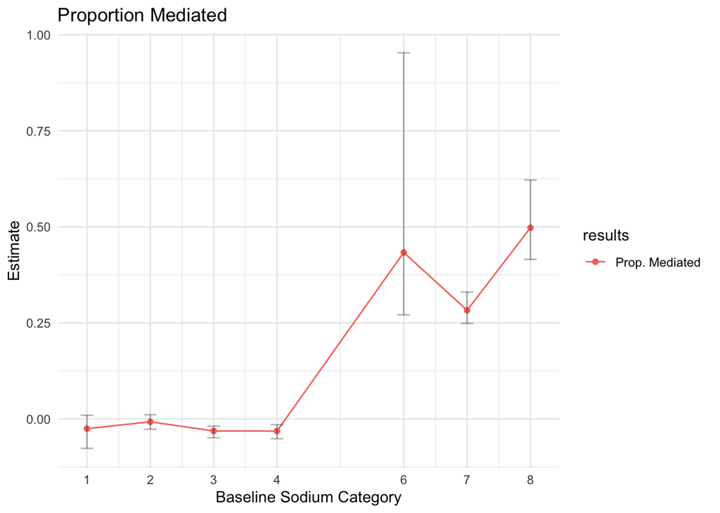

### Indirect Effect

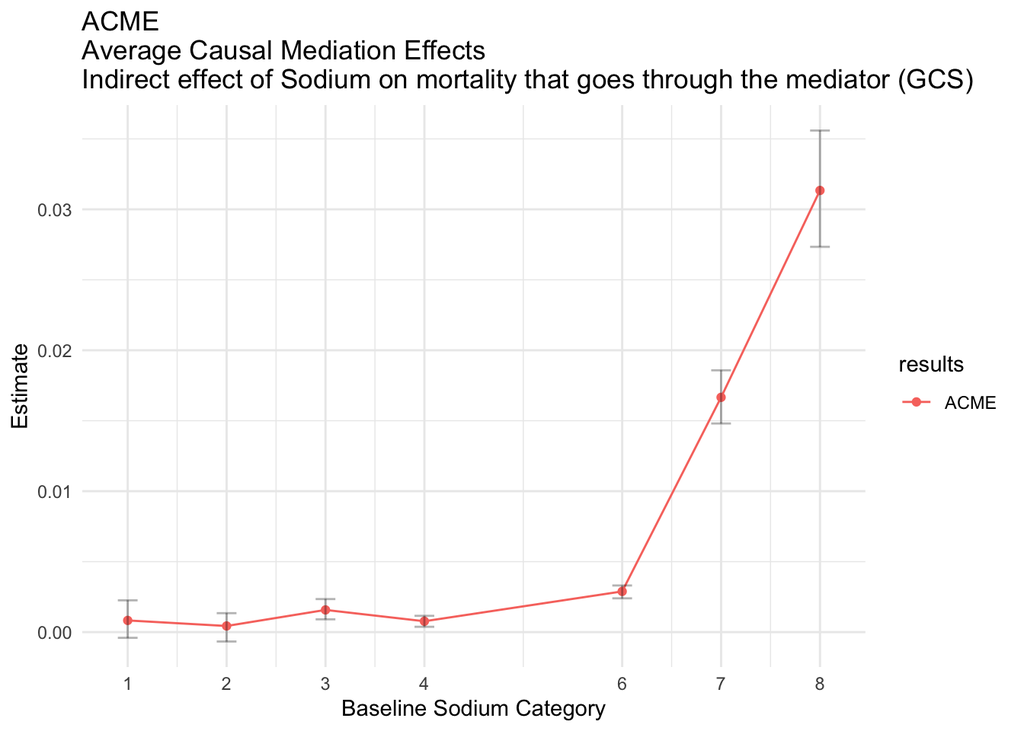

# Direct Effect

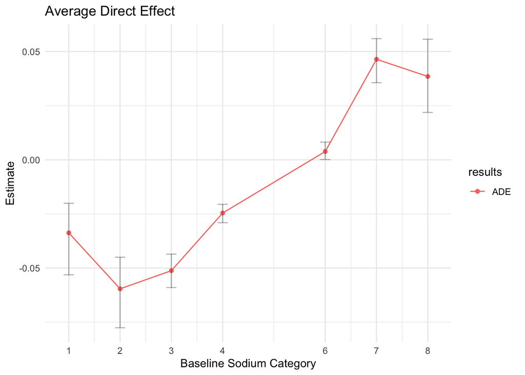

#Total Effect

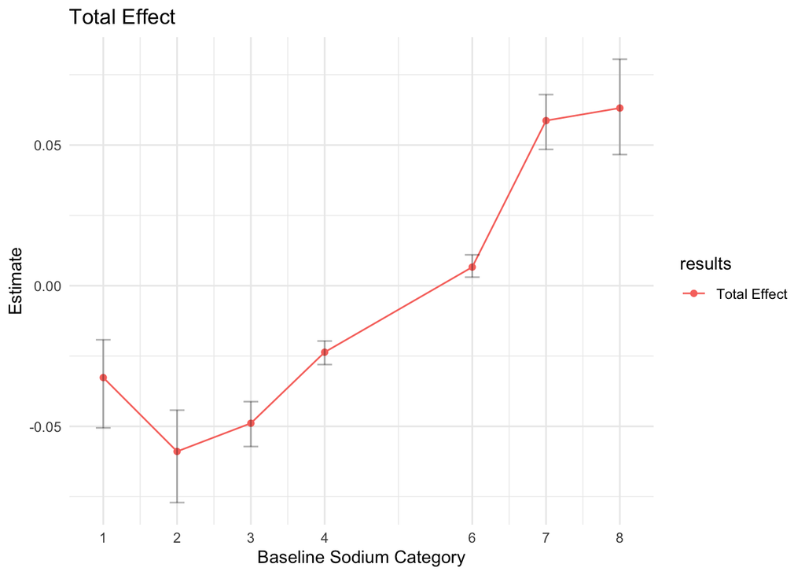